# Analyzing data on the level of cognitive processes - ESCoP 2025

Gidon T. Frischkorn, Ruhi Bhanap, and Isabel Courage

# Solutions: Exercise 5 - EZ-Diffusion Model (Color Judgement taks)

In this exercise, we will have a look at estimating the parameters from the diffusion decision model using the hierarchical Bayesian implementation of the ez-Diffusion Model. This implementation allows for a fast parameter estimation while still providing acceptable recovery of three parameters of interest:

1. drift rate = the rate of evidence accumulation
2. boundary separation = the separation of decision thresholds
3. non-decision time = the time for non-decisional processes.

Your task is to load one of the data sets we prepared for this exercise, either `excercise5_visual_search_task.txt` or `excercise5_color_judgement_task.txt`.

The *Color Judgement* data set contains data of 50 participants that completed a color judgement task. In this task participants saw an array of blue and red dots and should decide if the array contained more blue or red dots. There were two difficulty levels, the easy level in which 60% of the dots were either blue or red, and the difficult level in which 52% of the dots were either blue or red.

The *Visual Search* data set contains data for 33 participants that completed the visual search task. In this task, participants were presented a color cue, a positive (the target color), a negative (the non target color) or neutral (not part of the visual search display). Participants had to look for a “C” that either looked upwards or downwards and report it´s direction with the arrow key.

```r
# empty environment
rm(list = ls())

# Load required packages
library(bmm)
library(tidyverse)
library(here)
library(bayestestR)
```

### 1. Prepare data

First, we need to aggregate the data so that we can analyze our data with the `ezdm` using the `bmm` function. For this, we need to calculate the mean reaction time, the variance of the reaction time, the number of correct responses, and the number of trials in each of the four cells of the experimental design: easy - blue correct, easy - red correct, difficult - blue correct, and difficult - red correct.

```r
ezdm_data <- read.table(here("data","exercise5_color_judgement_task.txt"),
                        header = T, sep = ",")

ezdm_data_agg <- ezdm_data %>%
  filter(rt > 150, rt < 5000) %>%
  summarise(
    mrt = mean(rt/1000),
    vrt = var(rt/1000),
    n_correct = sum(correct),
    n_trials = n(),
    .by = c("participant_id", "condition", "correct_response")
  )

ezdm_data_agg$condition <- as.factor(ezdm_data_agg$condition)
contrasts(ezdm_data_agg$condition) <- contr.equalprior
```

### 2. Specify model object

Next, we need to specify the model object to link which data columns are used to identify the `ezdm`.

```r
ezdm_model <- bmm::ezdm(mean_rt = "mrt",
                        var_rt = "vrt",
                        n_upper = "n_correct",
                        n_trials = "n_trials")
```

### 3. Specify the BMM formula

Now, we can consider which parameters are affected by the experimental manipulations. First, let’s see how the `ezdm` parameters vary as a function of the difficulty manipulation.

```r
ezdm_formula <- bmf(
  drift ~ 1 + condition + (1 + condition | participant_id),
  bound ~  1 + (1 | participant_id),
  ndt ~  1 + condition + (1 + condition | participant_id)
)
```

### 4. Estimate `ezdm` with the `bmm` function

Finally, we can estimate the model using our aggregated data, the `bmmodel` object we created and the `bmmformula` specifying how the model parameters should change over experimental condition.

```r
ezdm_fit <- bmm(
  formula = ezdm_formula,
  data = ezdm_data_agg,
  model = ezdm_model,
  cores = 4,
  sample_prior = TRUE
  #file = here("models","ezdm_colortask")
)
```

[output not shown]

[output cut: 43 more lines]

```
## Chain 3 Iteration: 1900 / 2000 [ 95%]  (Sampling)
## Chain 1 Iteration: 1900 / 2000 [ 95%]  (Sampling)
## Chain 4 Iteration: 2000 / 2000 [100%]  (Sampling)
## Chain 4 finished in 26.1 seconds.
## Chain 2 Iteration: 1900 / 2000 [ 95%]  (Sampling)
## Chain 3 Iteration: 2000 / 2000 [100%]  (Sampling)
## Chain 3 finished in 26.6 seconds.
## Chain 1 Iteration: 2000 / 2000 [100%]  (Sampling)
## Chain 1 finished in 26.9 seconds.
## Chain 2 Iteration: 2000 / 2000 [100%]  (Sampling)
## Chain 2 finished in 27.1 seconds.
##
## All 4 chains finished successfully.
## Mean chain execution time: 26.7 seconds.
## Total execution time: 27.2 seconds.
```

We have a look at the model output:

```r
summary(ezdm_fit)
```

```
##   Model: bmm::ezdm(mean_rt = "mrt",
##                    var_rt = "vrt",
##                    n_upper = "n_correct",
##                    n_trials = "n_trials")
##   Links: drift = identity; bound = log; ndt = log; s = log
## Formula: drift ~ 1 + condition + (1 + condition | participant_id)
##          bound ~ 1 + (1 | participant_id)
##          ndt ~ 1 + condition + (1 + condition | participant_id)
##          s = 0
##    Data: ezdm_data_agg (Number of observations: 200)
##   Draws: 4 chains, each with iter = 2000; warmup = 1000; thin = 1;
##          total post-warmup draws = 4000
##
## Multilevel Hyperparameters:
## ~participant_id (Number of levels: 50)
##                                       Estimate Est.Error l-95% CI u-95% CI Rhat
## sd(drift_Intercept)                       0.49      0.05     0.40     0.61 1.01
## sd(drift_condition1)                      0.43      0.05     0.35     0.54 1.00
## sd(bound_Intercept)                       0.27      0.03     0.22     0.33 1.00
## sd(ndt_Intercept)                         0.27      0.04     0.20     0.37 1.00
## sd(ndt_condition1)                        0.15      0.04     0.09     0.23 1.00
## cor(drift_Intercept,drift_condition1)    -0.93      0.03    -0.97    -0.85 1.00
## cor(ndt_Intercept,ndt_condition1)        -0.20      0.25    -0.67     0.31 1.00
##                                       Bulk_ESS Tail_ESS
## sd(drift_Intercept)                        897     1619
## sd(drift_condition1)                      1117     1722
## sd(bound_Intercept)                        707     1126
## sd(ndt_Intercept)                         1469     1993
## sd(ndt_condition1)                        1133     1575
## cor(drift_Intercept,drift_condition1)     1530     2402
## cor(ndt_Intercept,ndt_condition1)         1791     1662
##
## Regression Coefficients:
##                  Estimate Est.Error l-95% CI u-95% CI Rhat Bulk_ESS Tail_ESS
## drift_Intercept      1.20      0.07     1.06     1.34 1.01      319      617
## bound_Intercept      0.63      0.04     0.55     0.70 1.01      342      720
## ndt_Intercept       -0.86      0.04    -0.94    -0.78 1.01      901     1834
## drift_condition1    -0.86      0.06    -0.98    -0.73 1.01      376      746
## ndt_condition1       0.26      0.03     0.19     0.33 1.00     1951     2601
##
## Constant Parameters:
##                 Value
## s_Intercept      0.00
##
## Draws were sampled using sample(hmc). For each parameter, Bulk_ESS
## and Tail_ESS are effective sample size measures, and Rhat is the potential
## scale reduction factor on split chains (at convergence, Rhat = 1).
```

Moreover, we test whether the estimates for the drift rate and non-decision time are substantial:

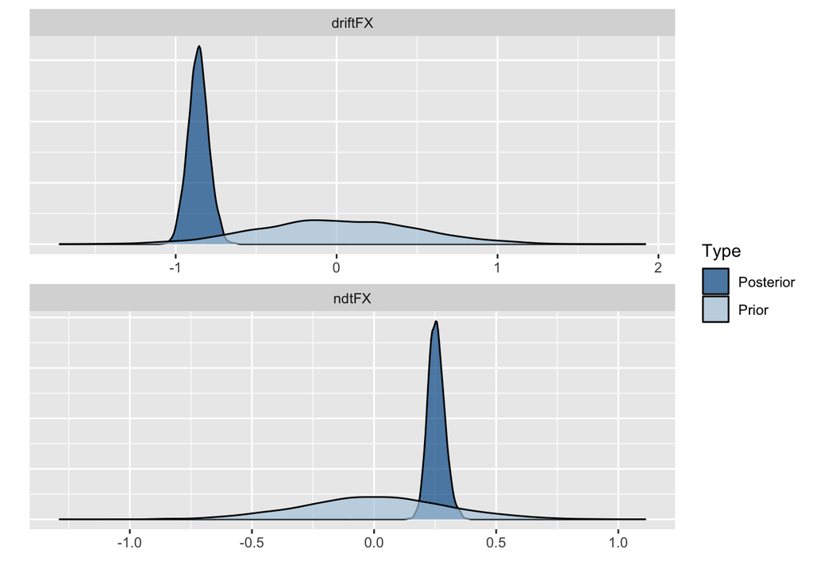

```r
ezdm_hypothesis <- c(
  driftFX = "drift_condition1 = 0",
  ndtFX = "ndt_condition1 = 0"
)

ezdm_hypothesis_results <- brms::hypothesis(
  ezdm_fit,
  ezdm_hypothesis
)

plot(ezdm_hypothesis_results)
```

```r
1/abs(ezdm_hypothesis_results$hypothesis$Evid.Ratio)
```

```
## [1]          Inf 1.714599e+28
```